# 市场观察

2017/01/20

## 一、IndexValuation指数估值

### (一)PEPB动态市盈率、市净率

核心指数成分股近18个月的动态市盈率及动态市净率中位数走势如下图所示：

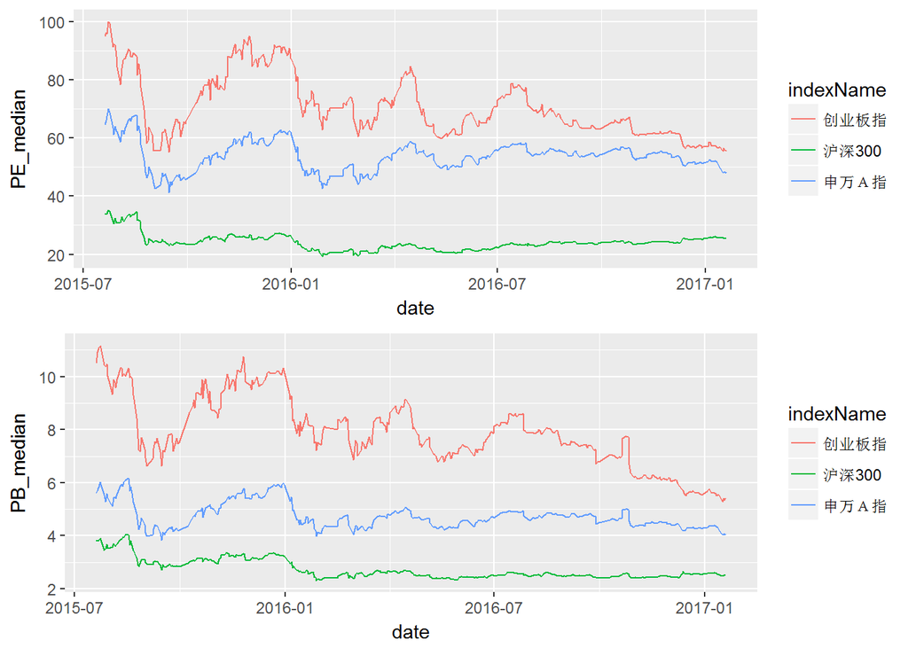

### (二)PEPBPercentile动态市盈率、市净率百分位

核心指数近18个月的动态市盈率百分位及动态市净率百分位走势如下图所示：

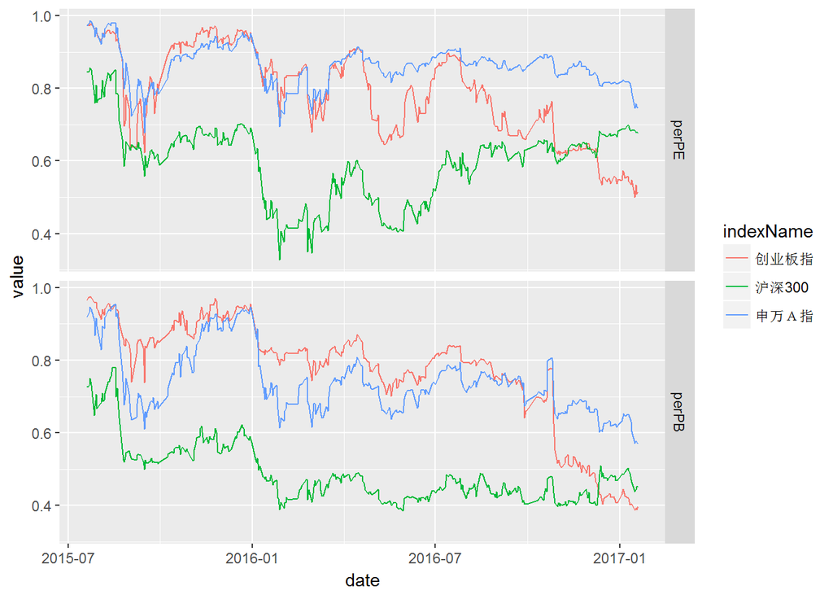

### (三)PEPB指数估值概览

纳入观察的18只指数最新的估值情况如下表：

| 日期 | 指数代码 | 指数简称 | 动态市盈率 | 市盈率百分位 | 动态市净率 | 市净率百分位 |
| --- | --- | --- | --- | --- | --- | --- |
| 2017-01-19 | EI000805 | A股资源 | 81.1 | 98.4% | 2.6 | 61.8% |
| 2017-01-19 | EI000979 | 大宗商品 | 53.3 | 95.4% | 2.9 | 66.8% |
| 2017-01-19 | EI000819 | 有色金属 | 56.5 | 77.2% | 3.3 | 47.8% |
| 2017-01-19 | EI801003 | 申万Ａ指 | 47.9 | 74.5% | 4.0 | 57.0% |
| 2017-01-19 | EI000808 | 医药生物 | 41.9 | 69.8% | 4.4 | 16.0% |
| 2017-01-19 | EI399330 | 深证100 | 32.8 | 67.8% | 3.8 | 56.6% |
| 2017-01-19 | EI000300 | 沪深300 | 25.4 | 67.6% | 2.5 | 45.3% |
| 2017-01-19 | EI000827 | 中证环保 | 41.8 | 66.4% | 3.0 | 24.0% |
| 2017-01-19 | EI399959 | 军工指数 | 85.1 | 64.0% | 5.3 | 66.1% |
| 2017-01-19 | EI399005 | 中小板指P | 40.1 | 60.8% | 4.5 | 39.0% |
| 2017-01-19 | EI000016 | 上证50 | 17.6 | 59.6% | 1.6 | 15.4% |
| 2017-01-19 | EI000933 | 中证医药 | 38.5 | 59.0% | 3.8 | 3.5% |
| 2017-01-19 | EI000905 | 中证500 | 38.2 | 56.3% | 3.0 | 35.9% |
| 2017-01-19 | EI000934 | 中证金融 | 18.2 | 55.8% | 1.9 | 28.3% |
| 2017-01-19 | EI399006 | 创业板指 | 55.9 | 51.6% | 5.4 | 39.7% |
| 2017-01-19 | EI000998 | 中证TMT | 42.1 | 41.9% | 4.2 | 35.7% |
| 2017-01-19 | EI801120 | 申万食品饮料 | 36.6 | 39.8% | 4.2 | 47.0% |
| 2017-01-19 | EI000932 | 中证消费 | 28.7 | 21.9% | 3.5 | 9.4% |

## 二、Spread基差

### (一)Spread基差走势

三大股指期货合约基差走势如下图，其中当月合约和次月合约年化基差百分比波动较大，仅展示合约基差百分比，当季合约和次季合约展示基差年化百分比：

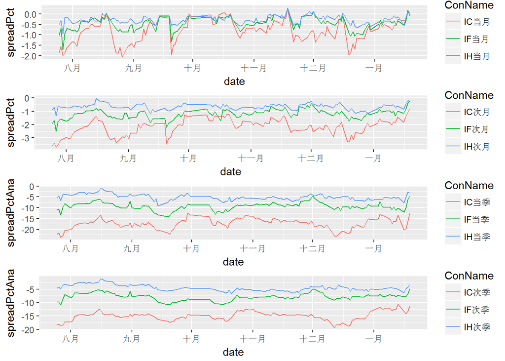

### (二)Spread基差概况

三大股指期货连续合约基差概况如下表，近月合约临近到期日，年化基差百分比数据波动较大：

| 日期 | 合约代码 | 合约收盘价 | 指数收盘价 | 基差 | 基差百分比 | 年化基差百分比 |
| --- | --- | --- | --- | --- | --- | --- |
| 2017-01-19 | IC1701 | 6047.0 | 6043.68 | 3.33 | 0.06% | 22.2% |
| 2017-01-19 | IC1702 | 5995.0 | 6043.68 | -48.67 | -0.81% | -10.6% |
| 2017-01-19 | IC1703 | 5931.4 | 6043.67 | -112.28 | -1.86% | -12.5% |
| 2017-01-19 | IC1706 | 5774.4 | 6043.67 | -269.27 | -4.46% | -11.3% |
| 2017-01-19 | IF1701 | 3326.0 | 3329.29 | -3.29 | -0.10% | -43.4% |
| 2017-01-19 | IF1702 | 3322.2 | 3329.29 | -7.09 | -0.21% | -2.7% |
| 2017-01-19 | IF1703 | 3305.8 | 3329.29 | -23.49 | -0.71% | -4.6% |
| 2017-01-19 | IF1706 | 3263.6 | 3329.29 | -65.69 | -1.97% | -4.9% |
| 2017-01-19 | IH1701 | 2334.0 | 2334.96 | -0.96 | -0.04% | -16.1% |
| 2017-01-19 | IH1702 | 2330.2 | 2334.96 | -4.76 | -0.20% | -2.6% |
| 2017-01-19 | IH1703 | 2324.0 | 2334.96 | -10.96 | -0.47% | -3.0% |
| 2017-01-19 | IH1706 | 2304.0 | 2334.96 | -30.96 | -1.33% | -3.3% |

## 三、Arbitrage套利

### (一)Arbitrage复牌股票套利

近两天复牌股票套利情况如下表：

[1] “无复牌股票套利”

### (二)Arbitrage定增基金跟踪

截止2017-01-20定增基金数据如下表，明细数据参见钱瀚的模板。

| 代码 | 名称 | 到期日期 | 最新净值 | 昨日收盘价 | 折溢价率 | 整体隐含折价率 | 大盘下跌0.1净值变化 |
| --- | --- | --- | --- | --- | --- | --- | --- |
| 168101.OF | 九泰锐智 | 20200814 | 1.14 | 1.07 | -5.9% | 4.3% | -8.9% |
| 168102.OF | 九泰锐富 | 20210204 | 1.01 | 0.92 | -8.5% | 2.9% | -4.7% |
| 501015.OF | 财通升级 | 20170908 | 1.01 | 0.99 | -2.0% | 4.6% | -7.8% |
| 160518.OF | 博时睿远 | 20171016 | 0.96 | 0.93 | -2.9% | 1.9% | -5.9% |

定增基金近期的净值走势如下图：

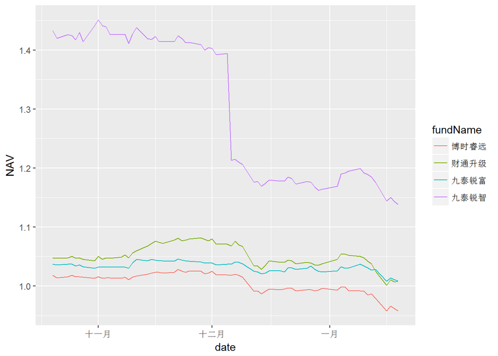

定增基金近期的折溢价率百分比走势如下图：

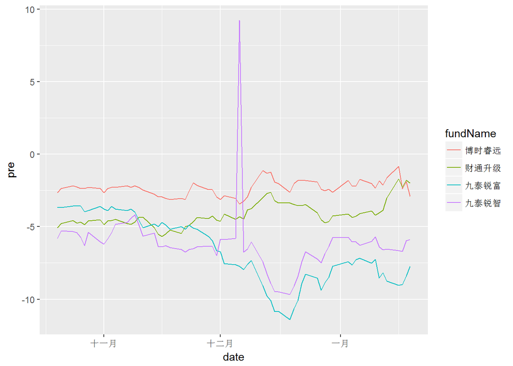

## 四、Timing择时

### (一)EqualWeightIndex等权指数

从历史来看，A股市场存在小盘股效应，市值小的股票长期整体跑赢大市值的股票，美股市场同样存在类似的现象。而目前大部分指数的编制方案都是类似市值加权，为了抛去市值的影响，下面展示几个等权指数，其中中证500等权和沪深300等权是现有的指数，中证全指等权是自己编制的指数。等权指数可以视为一个更好地业绩比较基准。等权指数走势如下图：

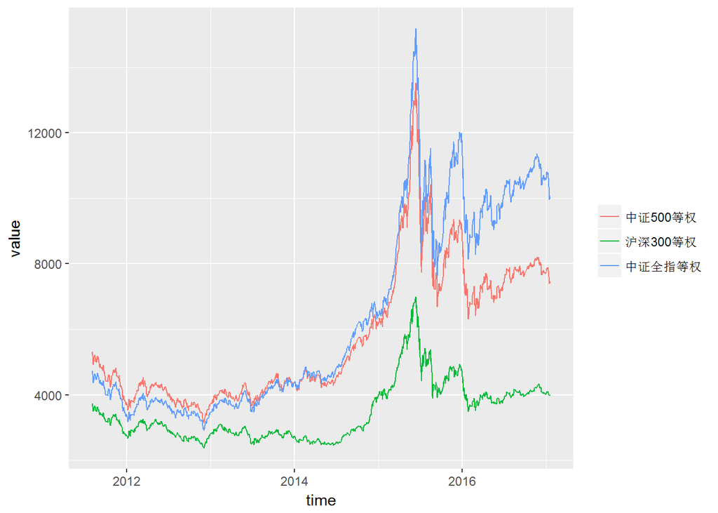

等权指数收益率统计见下表：

|  | 中证500等权 | 沪深300等权 | 中证全指等权 |
| --- | --- | --- | --- |
| 2011-08-02 ~ 2011-12-30 | -29.2% | -25.5% | -28% |
| 2012-01-04 ~ 2012-12-31 | 0.0% | 1.5% | 2% |
| 2013-01-04 ~ 2013-12-31 | 16.7% | -3.2% | 26% |
| 2014-01-02 ~ 2014-12-31 | 40.2% | 43.7% | 46% |
| 2015-01-05 ~ 2015-12-31 | 47.6% | 20.1% | 84% |
| 2016-01-04 ~ 2016-12-30 | -15.1% | -15.1% | -10% |
| 2017-01-03 ~ 2017-01-19 | -3.8% | -0.9% | -5% |
| 累计收益率 | 39.7% | 6.5% | 112% |
| 年化收益率 | 6.3% | 1.1% | 15% |
| 年化波动率 | 29.2% | 26.5% | 30% |
| 年化Sharpe值 | 21.6% | 4.3% | 50% |
| 最大回撤 | 53.3% | 50.0% | 50% |

### (二)Timing大盘均线强弱指数

大盘均线强弱指数在一定程度上可以视为一个反转指标，当大盘均线得分接近8分时，预示市场接近顶部，当大盘均线得分接近0分时，预示市场接近底部。  
大盘均线强弱指数近一年来走势如下图：

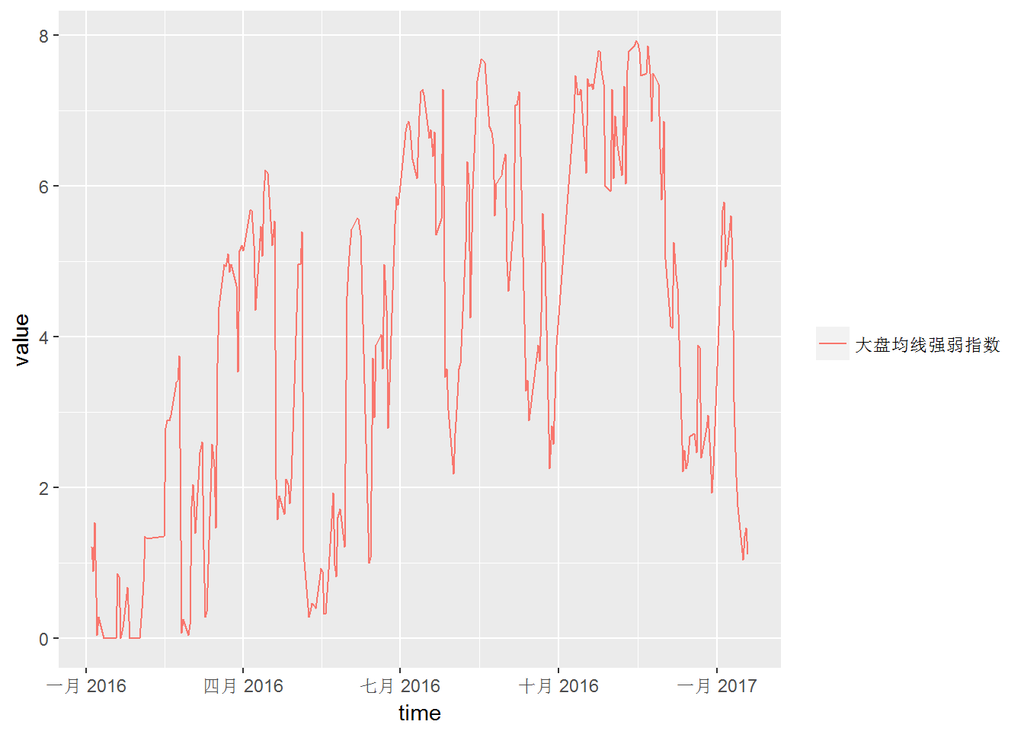

申万一级行业的最新得分见下表：

| 日期 | 指数代码 | 行业 | 最新得分 | 上周得分 |
| --- | --- | --- | --- | --- |
| 2017-01-19 | EI801780 | 银行 | 8 | 5 |
| 2017-01-19 | EI801040 | 钢铁 | 6 | 7 |
| 2017-01-19 | EI801120 | 食品饮料 | 3 | 3 |
| 2017-01-19 | EI801110 | 家用电器 | 2 | 2 |
| 2017-01-19 | EI801710 | 建筑材料 | 2 | 2 |
| 2017-01-19 | EI801720 | 建筑装饰 | 2 | 3 |
| 2017-01-19 | EI801740 | 国防军工 | 2 | 7 |
| 2017-01-19 | EI801020 | 采掘 | 1 | 2 |
| 2017-01-19 | EI801030 | 化工 | 1 | 2 |
| 2017-01-19 | EI801160 | 公用事业 | 1 | 1 |
| 2017-01-19 | EI801200 | 商业贸易 | 1 | 3 |
| 2017-01-19 | EI801790 | 非银金融 | 1 | 3 |
| 2017-01-19 | EI801880 | 汽车 | 1 | 1 |
| 2017-01-19 | EI801010 | 农林牧渔 | 0 | 1 |
| 2017-01-19 | EI801050 | 有色金属 | 0 | 0 |
| 2017-01-19 | EI801080 | 电子 | 0 | 0 |
| 2017-01-19 | EI801130 | 纺织服装 | 0 | 1 |
| 2017-01-19 | EI801140 | 轻工制造 | 0 | 1 |
| 2017-01-19 | EI801150 | 医药生物 | 0 | 1 |
| 2017-01-19 | EI801170 | 交通运输 | 0 | 0 |
| 2017-01-19 | EI801180 | 房地产 | 0 | 1 |
| 2017-01-19 | EI801210 | 休闲服务 | 0 | 0 |
| 2017-01-19 | EI801230 | 综合 | 0 | 1 |
| 2017-01-19 | EI801730 | 电气设备 | 0 | 0 |
| 2017-01-19 | EI801750 | 计算机 | 0 | 0 |
| 2017-01-19 | EI801760 | 传媒 | 0 | 0 |
| 2017-01-19 | EI801770 | 通信 | 0 | 1 |
| 2017-01-19 | EI801890 | 机械设备 | 0 | 1 |

### (三)LLT及均线择时

LLT本质上是一个改进的单均线择时指标，较原始的均线择时延迟更低。  
择时模型和指数本身的净值走势如下图：

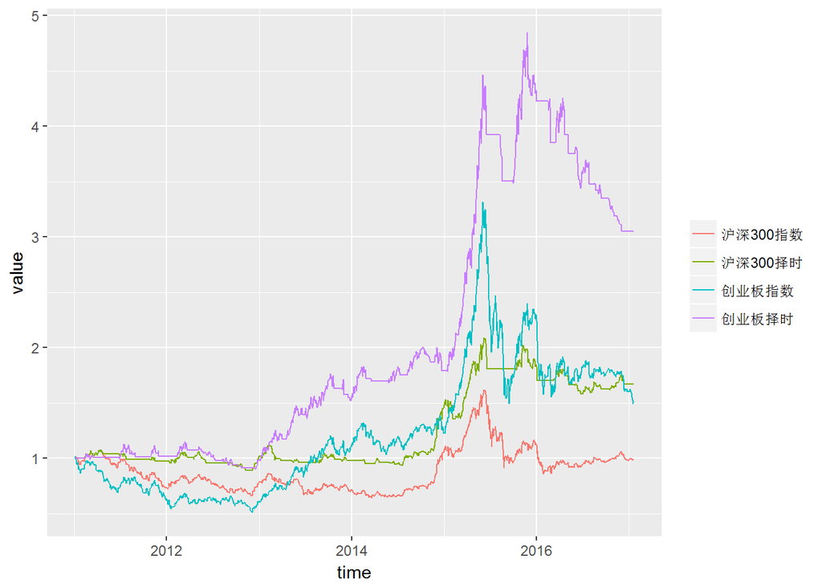

择时模型和指数的收益率统计如下表：

|  | 沪深300指 | 沪深300LLT | 创业板指 | 创业板MA |
| --- | --- | --- | --- | --- |
| 2011-01-04 ~ 2011-12-30 | -25.9% | -2.9% | -37% | 1% |
| 2012-01-04 ~ 2012-12-31 | 6.1% | 4.8% | -3% | -2% |
| 2013-01-04 ~ 2013-12-31 | -8.7% | -3.7% | 81% | 54% |
| 2014-01-02 ~ 2014-12-31 | 49.8% | 51.3% | 11% | 17% |
| 2015-01-05 ~ 2015-12-31 | 4.3% | 23.4% | 82% | 136% |
| 2016-01-04 ~ 2016-12-30 | -12.4% | -8.7% | -29% | -28% |
| 2017-01-03 ~ 2017-01-19 | 0.5% | 0.0% | -6% | 0% |
| 累计收益率 | -1.2% | 67.1% | 51% | 205% |
| 年化收益率 | -0.2% | 8.9% | 7% | 20% |
| 年化波动率 | 24.5% | 15.7% | 33% | 22% |
| 年化Sharpe值 | -0.8% | 56.6% | 21% | 90% |
| 最大回撤 | 47.1% | 24.4% | 55% | 37% |

择时模型最近10个交易日的信号如下表：

| 日期 | 沪深300收盘价 | 沪深300LLT | 沪深300择时信号 | 创业板收盘价 | 创业板MA30 | 创业板择时信号 |
| --- | --- | --- | --- | --- | --- | --- |
| 2017-01-06 | 3347.666 | 3396.711 |  | 1965.030 | 2038.489 |  |
| 2017-01-09 | 3363.901 | 3394.946 |  | 1961.619 | 2031.626 |  |
| 2017-01-10 | 3358.272 | 3393.596 |  | 1951.677 | 2024.480 |  |
| 2017-01-11 | 3334.495 | 3391.343 |  | 1937.547 | 2017.053 |  |
| 2017-01-12 | 3317.624 | 3387.865 |  | 1930.145 | 2008.623 |  |
| 2017-01-13 | 3319.912 | 3384.071 |  | 1899.943 | 1999.224 |  |
| 2017-01-16 | 3319.445 | 3380.510 |  | 1830.848 | 1988.804 |  |
| 2017-01-17 | 3326.356 | 3377.323 |  | 1867.868 | 1979.603 |  |
| 2017-01-18 | 3339.365 | 3374.931 |  | 1845.787 | 1970.388 |  |
| 2017-01-19 | 3329.289 | 3372.743 |  | 1844.140 | 1960.693 |  |

### (四)GridTrade网格交易

在经历了三轮股灾，A股逐步回归正常，在过去的一段时间呈现一个震荡的格局，如果未来没有增量信息，很可能维持震荡。结合股指期货的贴水，前期研究了一下网格交易。网格交易的结果如下图：

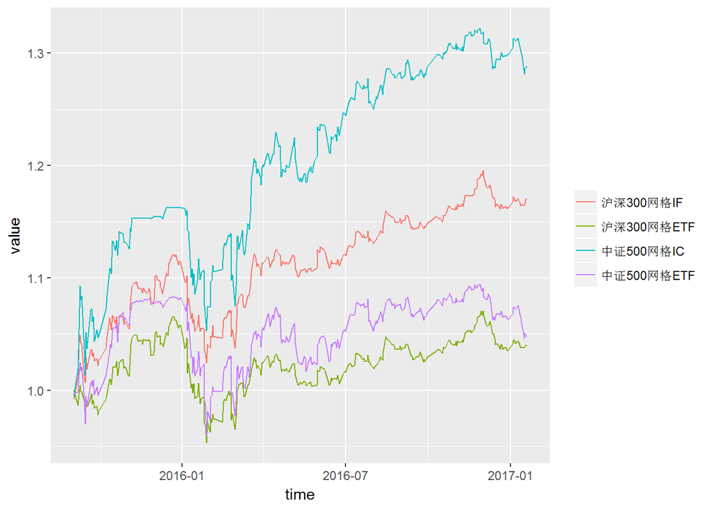

网格交易沪深300股指期货的最新仓位是33.9%，中证500股指期货的最新仓位是36.8%,网格交易的收益统计如下表：

|  | 沪深300指数 | 沪深300网格IF | 沪深300网格ETF | 中证500指数 | 中证500网格IC | 中证500网格ETF |
| --- | --- | --- | --- | --- | --- | --- |
| 2015-09-02 ~ 2015-12-31 | 11.0% | 11% | 5.6% | 23.5% | 16% | 8.1% |
| 2016-01-04 ~ 2016-12-30 | -11.3% | 5% | -1.8% | -17.8% | 12% | -1.6% |
| 2017-01-03 ~ 2017-01-19 | 0.6% | 1% | 0.2% | -3.5% | -1% | -1.5% |
| 累计收益率 | -1.0% | 17% | 3.9% | -2.0% | 29% | 4.8% |
| 年化收益率 | -0.7% | 12% | 2.8% | -1.5% | 20% | 3.4% |
| 年化波动率 | 23.2% | 10% | 9.4% | 31.2% | 14% | 12.1% |
| 年化Sharpe值 | -3.0% | 124% | 29.9% | -4.7% | 140% | 28.0% |
| 最大回撤 | 26.4% | 9% | 10.5% | 33.5% | 9% | 11.4% |

## 五、选股

### (一)SmallStock超级小盘股

作为多因子选股的第一部分，有必要从市值因子说起。 下面利用总市值因子，在中证全指的成分股内，选出市值最小的100只股票，这里剔除了ST、新上市、停牌和涨停的股票，100只股票等权配置，每月换仓一次，交易成本千分之三。超级小盘股策略的净值表现如下图。

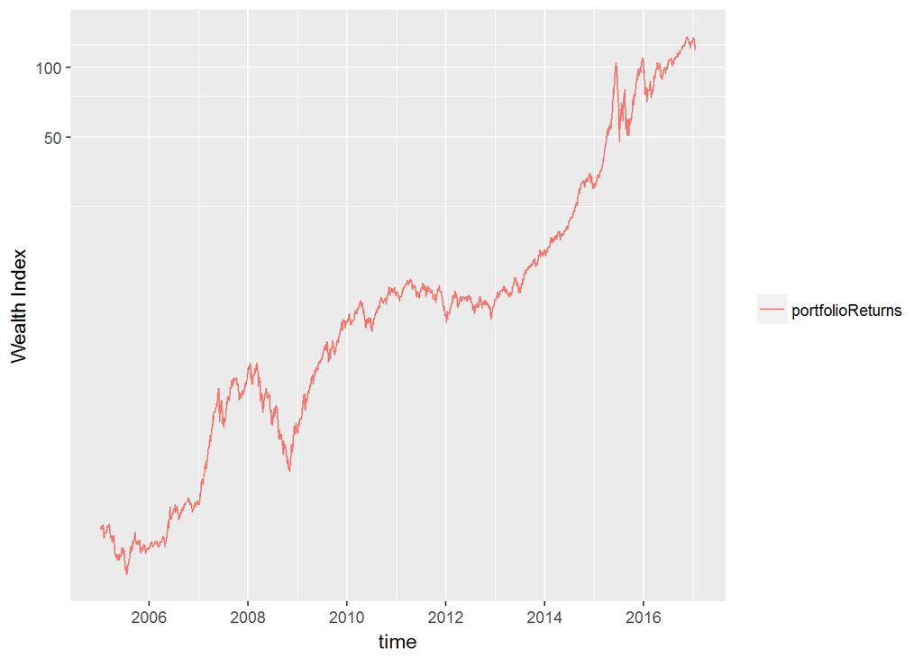

超级小盘股的收益统计如下表：

|  | 超级小盘股 | 沪深300 | 中证500 |
| --- | --- | --- | --- |
| 2005-01-05 ~ 2005-12-30 | -17% | -6% | -13% |
| 2006-01-04 ~ 2006-12-29 | 56% | 121% | 101% |
| 2007-01-04 ~ 2007-12-28 | 265% | 162% | 187% |
| 2008-01-02 ~ 2008-12-31 | -45% | -66% | -61% |
| 2009-01-05 ~ 2009-12-31 | 206% | 97% | 131% |
| 2010-01-04 ~ 2010-12-31 | 32% | -13% | 10% |
| 2011-01-04 ~ 2011-12-30 | -19% | -25% | -34% |
| 2012-01-04 ~ 2012-12-31 | 15% | 8% | 0% |
| 2013-01-04 ~ 2013-12-31 | 63% | -8% | 17% |
| 2014-01-02 ~ 2014-12-31 | 89% | 52% | 39% |
| 2015-01-05 ~ 2015-12-31 | 254% | 6% | 43% |
| 2016-01-04 ~ 2016-12-30 | 21% | -11% | -18% |
| 2017-01-03 ~ 2017-01-19 | -9% | 1% | -4% |
| 累计收益率 | 11802% | 239% | 514% |
| 年化收益率 | 49% | 11% | 16% |
| 年化波动率 | 36% | 29% | 33% |
| 年化Sharpe值 | 135% | 37% | 50% |
| 最大回撤 | 66% | 72% | 72% |

### (二)BankRotation银行股轮动

银行股轮动是参考集思录的热门贴银行股评级而来的，数据的提取和参数的设置和原贴有一定的差别，所以轮动的效果也会不太一样，不过回测的效果还不错，从现在开始跟踪。2013年以来银行股轮动的结果如下图：

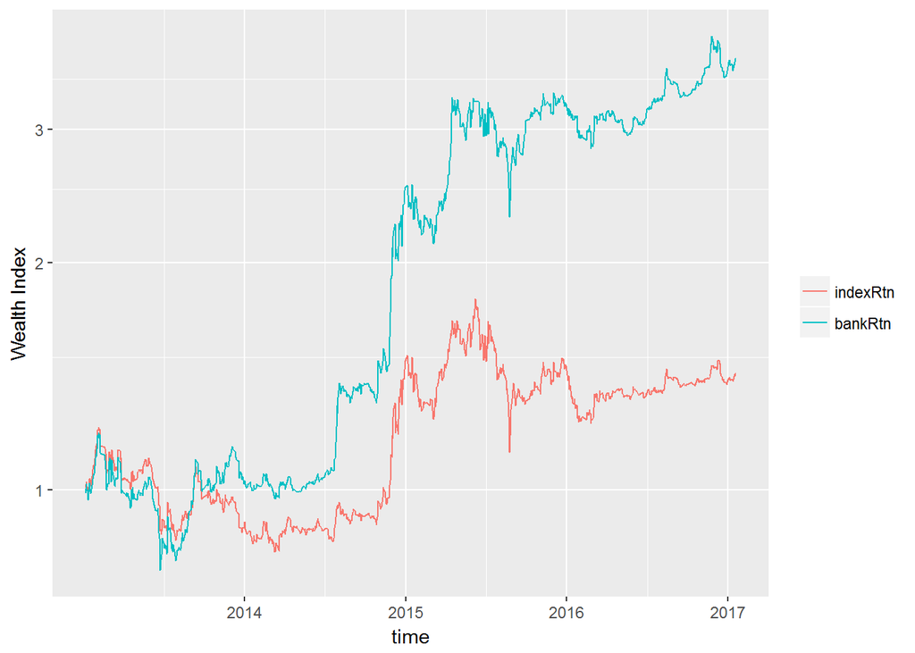

银行股轮动的收益统计如下表：

|  | 申万银行 | 银行股轮动 |
| --- | --- | --- |
| 2013-01-04 ~ 2013-12-31 | -9.2% | 3% |
| 2014-01-02 ~ 2014-12-31 | 63.2% | 145% |
| 2015-01-05 ~ 2015-12-31 | -1.4% | 29% |
| 2016-01-04 ~ 2016-12-30 | -4.9% | 10% |
| 2017-01-03 ~ 2017-01-19 | 2.6% | 4% |
| 累计收益率 | 42.5% | 273% |
| 年化收益率 | 9.1% | 38% |
| 年化波动率 | 28.8% | 33% |
| 年化Sharpe值 | 31.7% | 117% |
| 最大回撤 | 37.4% | 34% |

银行股轮动的最新得分如下表：

| 日期 | 代码 | 简称 | PB | 预期ROE | 翻倍期 | 持仓 |
| --- | --- | --- | --- | --- | --- | --- |
| 2017-01-19 | EQ601818 | 光大银行 | 0.75 | 0.12 | 3.48 |  |
| 2017-01-19 | EQ601328 | 交通银行 | 0.72 | 0.10 | 3.61 |  |
| 2017-01-19 | EQ600015 | 华夏银行 | 0.81 | 0.14 | 3.64 | hold |
| 2017-01-19 | EQ601988 | 中国银行 | 0.75 | 0.11 | 3.75 |  |
| 2017-01-19 | EQ601288 | 农业银行 | 0.78 | 0.12 | 3.88 |  |
| 2017-01-19 | EQ000001 | 平安银行 | 0.80 | 0.12 | 4.01 |  |
| 2017-01-19 | EQ601398 | 工商银行 | 0.83 | 0.13 | 4.22 |  |
| 2017-01-19 | EQ601166 | 兴业银行 | 0.92 | 0.14 | 4.59 |  |
| 2017-01-19 | EQ601939 | 建设银行 | 0.90 | 0.14 | 4.63 |  |
| 2017-01-19 | EQ600000 | 浦发银行 | 0.99 | 0.15 | 5.07 |  |
| 2017-01-19 | EQ601009 | 南京银行 | 1.13 | 0.15 | 5.87 |  |
| 2017-01-19 | EQ600016 | 民生银行 | 1.03 | 0.13 | 6.06 |  |
| 2017-01-19 | EQ601169 | 北京银行 | 1.08 | 0.13 | 6.07 |  |
| 2017-01-19 | EQ600036 | 招商银行 | 1.18 | 0.15 | 6.24 |  |
| 2017-01-19 | EQ601998 | 中信银行 | 0.98 | 0.11 | 6.34 |  |
| 2017-01-19 | EQ002142 | 宁波银行 | 1.36 | 0.16 | 6.83 |  |
| 2017-01-19 | EQ600919 | 江苏银行 | 1.34 | 0.13 | 7.98 |  |
| 2017-01-19 | EQ601997 | 贵阳银行 | 1.71 | 0.16 | 8.07 |  |
| 2017-01-19 | EQ601229 | 上海银行 | 1.31 | 0.12 | 8.52 |  |
| 2017-01-19 | EQ600926 | 杭州银行 | 1.47 | 0.10 | 11.65 |  |
| 2017-01-19 | EQ601128 | 常熟银行 | 2.07 | 0.10 | 14.40 |  |
| 2017-01-19 | EQ600908 | 无锡银行 | 2.01 | 0.10 | 14.63 |  |
| 2017-01-19 | EQ002807 | 江阴银行 | 1.96 | 0.09 | 15.60 |  |
| 2017-01-19 | EQ603323 | 吴江银行 | 2.07 | 0.08 | 18.16 |  |